# act_report

## Report: act_report

- Create a **250-word-minimum written report** called "act_report.pdf" or "act_report.html" that communicates the insights and displays the visualization(s) produced from your wrangled data. This is to be framed as an external document, like a blog post or magazine article, for example.

[figure not shown]

Le but de ce projet était de collecter, nettoyer et rapporter un jeu de données composé de 3 fichiers distincts en procédant par 3 différentes méthodes de collecte.

Les jeux de donnees fournies proviennent du compte tweeter de **WeRateDogs**

Après avoir effectué le travail dans son ensemble, nous avons produit le nouveau jeu de données "twitter_archive_master.csv". Ce jeu de données est constitué de 40 colonnes et 2073 lignes. N'ayant pas entièrement nettoyé le jeu de données nous constatons qu'il existe encore quelques erreurs et qu'il serait important de les corriger.

Notamment on constate que la colonne timestamp lorsqu'elle est utilisée à partir du fichier csv n'a plus le format datetime. Nous observons que notre dataframe final s'étend du 16-11-2015 au 01-08-2017. Notre jeu de données nous permet d'observer les données de chiens partant des images pour avoir des scores de notation et des nombres de tweets.

En fonction des caractéristiques de chiens nous avons dans notre classement 4 types de chiens a savoir 'doggo','pupper', 'puppo' et 'floofer'. Nous avons décidé d'observer la prépondérence de ces types dans notre jeu de données.

Pour notre visualisation, nous avons décidé de présenter le plus grand nombre de types de chiens. Il s'agit alors de Pupper.

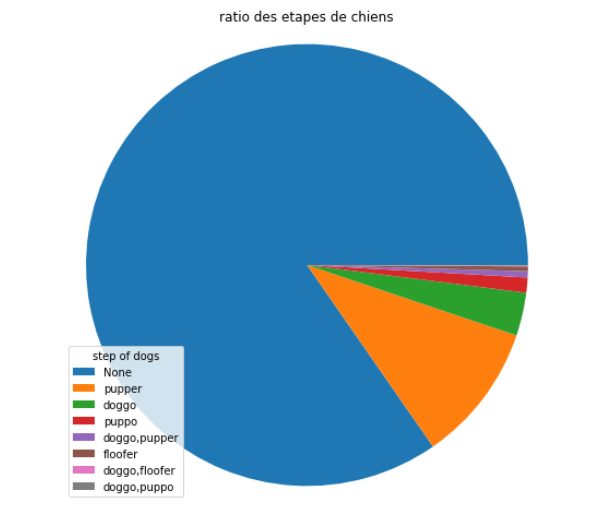